## Report: act_report

# Twitter Analytics: “WeRateDogs”

[figure not shown]

WeRateDogs is a Twitter account that rates people’s dogs with humorous comments.The dataset is gotten from the tweet archive of Twitter user @dog_rates, an additional data from Twitter API and an image prdiction file gotten from a neural network.

## Insights and Visualization

The data has been gathered, assessed, cleaned, stored and has been analyzed. some research questions were asked and answered, below are the findings.

### Question 1: What are the top 5 most common dog breed

From the chart, we can see the 5 most common dog breed with the Golden Retriever championing the list. These dogs have most tweets on them, which has led them on our most common list.

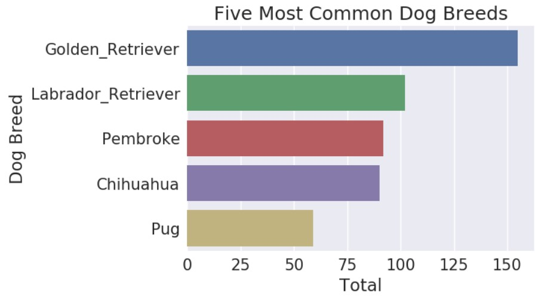

Below is an image of the Golden retriever which is the most common dog breed that is uploaded to WeRateDogs twitter page for rating.

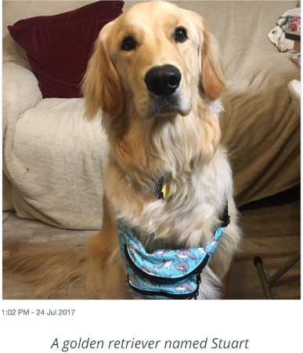

### Question 2: What dog breed has the highest retweet count

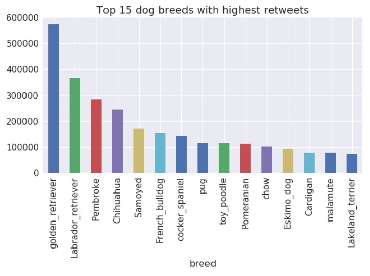

The golden_retriever is also the breed with the most retweets. With this particular breed being the most common, it is only natural for it to also be the breed with the most engagement on WeRateDogs page. I mean are they so cute and lovable.

### Question 2: Counts for dog stages

What are these dog stages?

- Pupper: A pupper is a small doggo, usually younger. Can be equally if not more mature than some doggos.
- Doggo: A doggo is a big pupper, usually older. It appears to have its life in order. Probably understands taxes and whatnot.
- Puppo: A puppo is a transitional phase between pupper and doggo. Easily understood as the dog’s equivalent of a teenager.
- Floof(er): This is basically any dog that has excess fur.

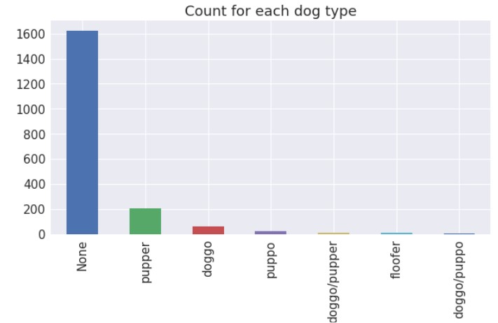

Although we have four stages of dogs in our dataset, we do have some dogs belonging to two stages. The pupper appears to be the most reoccuring stage. But we cannot make that inference as we have a lot of tweets where the dog stage were not stated. Therefore, it is impossible to draw accurate conclusions about the overall stages of the dogs.